# **Generalized Additive Models**

andrés castro araújo

Dec 26, 2019

> All of this is taken from Noam Ross’ online course, [*Generalized Additive Models in R*](https://noamross.github.io/gams-in-r-course/).

Note: Include the `family` argument in the `gam()` function to extend other types of generalized linear models.

## Introduction

In terms of interpretability, Generalized Additive Models (GAMs) are a middle-ground between linear regression and black-box types of machine learning.

*Hello world!*

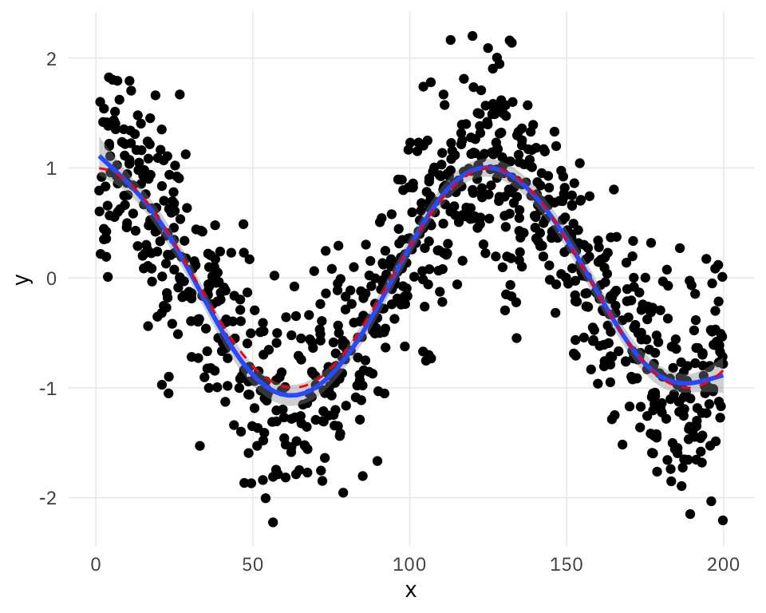

```r
N <- 1e3
x <- runif(N, 1, 200)
y <- rnorm(N, mean = cos(0.05*x), sd = 0.5)

tibble(x, y) %>%
  ggplot(aes(x, y)) +
  geom_point() +
  geom_smooth(method = mgcv::gam, formula = y ~ s(x)) +
  stat_function(fun = function(x) cos(0.05*x), linetype = "dashed", color = "red")
```

> We fit a GAM using the `gam()` function from the mgcv package. Here, when we fit this GAM, we wrap the independent variable, `x`, in the `s()`, that is smooth function to specify that we want this relationship to be flexible. A GAM can capture the nonlinear aspects of not only this relationship, but of many nonlinear relationships, because of the flexibility of *splines*.

> The flexible smooths in GAMs are actually constructed of many smaller functions. These are called **basis functions**. Each smooth line is the sum of a number of basis functions, and each basis function is multiplied by a coefficient, each of which is a parameter in the model. In the plot here on the left, we show the basis functions of a GAM where all the coefficients are the same. On the right, we show the same basis functions after model-fitting, where each has a coefficient fit to the data. You can see how these basis functions add up to create the overall smooth shape. So a single nonlinear relationship between a dependent and independent variable has several parameters, plus an intercept. This is different, and more complex, than a linear model, where each variable has only a single coefficient or parameter.

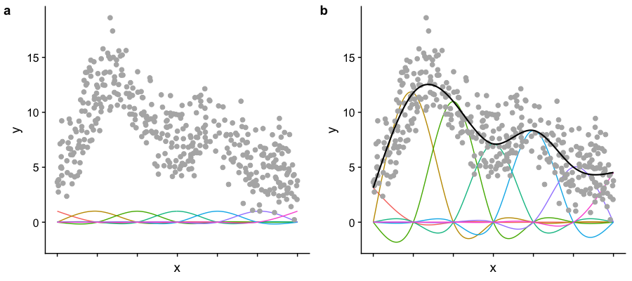

```r
library(mgcv)

tibble(x, y) %>% head()
```

```
# A tibble: 6 x 2
      x      y
  <dbl>  <dbl>
1 178.  -1.44
2 154.   0.702
3 174.  -0.242
4  96.0 -0.187
5  50.5 -0.939
6 130.   1.02
```

```r
model.matrix(gam(y ~ s(x))) %>% head()
```

```
  (Intercept)     s(x).1      s(x).2      s(x).3      s(x).4     s(x).5
1           1  1.1157675 -0.48573012  1.36328040 -0.50853609 -1.3480937
2           1  1.0024870 -0.23628621  0.82000976  0.05726256 -0.5254289
3           1  1.1089824 -0.45588350  1.31456074 -0.43288361 -1.2385747
4           1 -0.1798133  0.53917218  0.02569295  0.06606591  0.1895342
5           1 -1.0825246 -0.01314714 -0.79610020  0.33400004  0.4893460
6           1  0.6533575  0.23766724  0.07032153  0.30289420 -0.3652665
        s(x).6      s(x).7       s(x).8     s(x).9
1 -0.499058336 -1.30365053 -0.222126180  1.2990814
2  0.142991765 -0.56780829  0.207136215  0.8842009
3 -0.368534631 -1.13560767 -0.144588177  1.2270388
4  0.382765088 -0.04536212  0.505080658 -0.1209304
5  0.380780388  0.65081175  0.002879188 -0.9056954
6  0.006382403 -0.40328690  0.443873256  0.4573744
```

```r
model.matrix(gam(y ~ s(x))) %>% dim()
```

```
[1] 1000   10
```

```r
gam_mod <- gam(y ~s(x))
gam_mod
```

```
Family: gaussian
Link function: identity

Formula:
y ~ s(x)

Estimated degrees of freedom:
8.3  total = 9.3

GCV score: 0.2497324
```

```r
coefficients(gam_mod)
```

```
(Intercept)      s(x).1      s(x).2      s(x).3      s(x).4      s(x).5
-0.03273651  2.46788169  2.73972650 -1.00880300  0.80716246  0.07545898
     s(x).6      s(x).7      s(x).8      s(x).9
 0.91405787 -0.10136181 -2.74584144 -0.50656484
```

## Basis Functions

How do GAMs navigate the tradeoff under-fitting and over-fitting? GAMs penalize the “complexity” or “wiggliness” of the fitted model.

$$\text{fit} = \text{likelihood} - \lambda \ \text{wiggliness} \hspace{1cm} \text{where} \ \lambda = \text{smoothing parameter}$$

**The smoothing parameter**

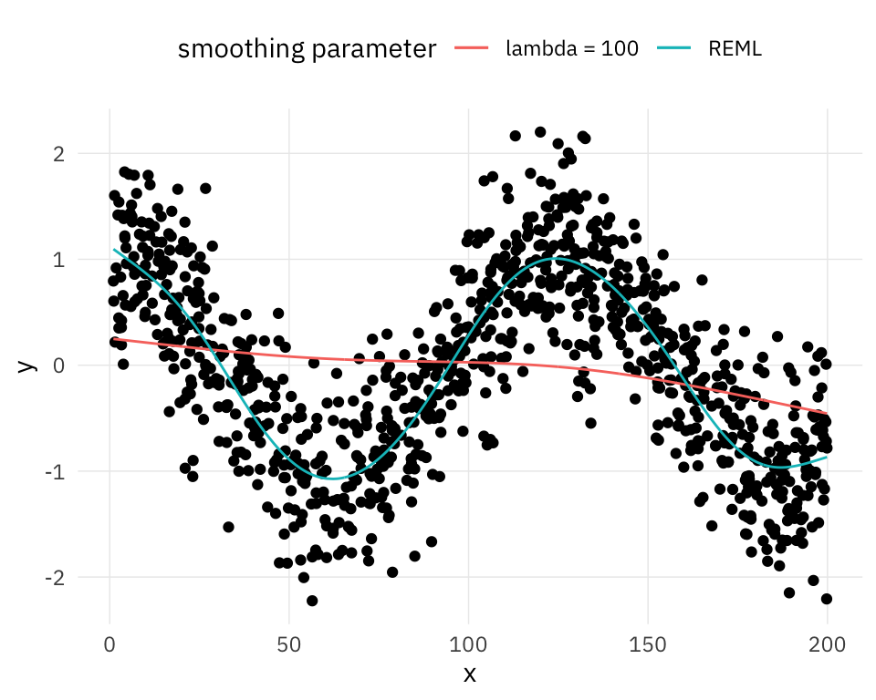

```r
large_sp <- gam(y ~ s(x, sp = 100))         ## sp too large
reml_sp <- gam(y ~ s(x), method = "REML")   ## restricted via maximul likelihood

tibble(x, y, large = predict(large_sp), reml = predict(reml_sp)) %>%
  ggplot(aes(x, y)) +
  geom_point() +
  geom_line(aes(y = large, color = "lambda = 100")) +
  geom_line(aes(y = reml, color = "REML")) +
  theme(legend.position = "top") +
  labs(color = "smoothing parameter")
```

> In addition to the smoothing parameter, the other factor that affects how wiggly a GAM function can be is the number of basis functions that make up a smooth function.

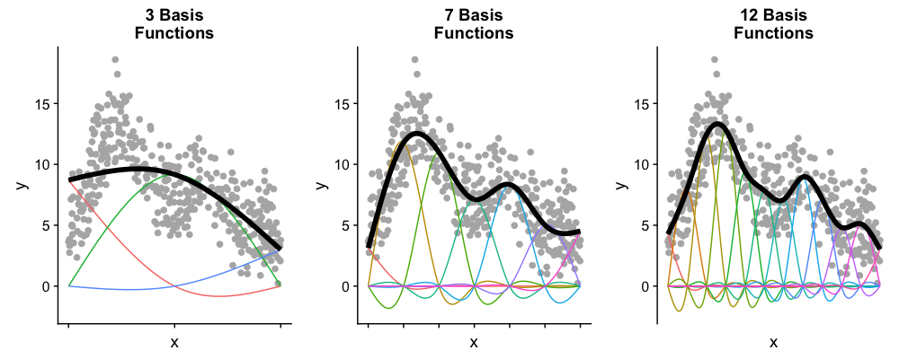

> As you can see, a smooth with a small number of basis functions is limited in its wiggliness, while one with many basis functions is capable of capturing finer patterns.

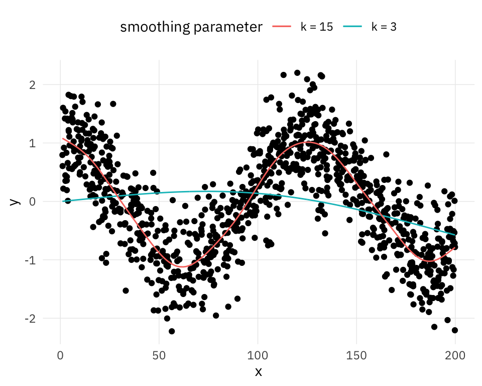

```r
k3 <- gam(y ~ s(x, k = 3), method = "REML") %>% predict()
k15 <- gam(y ~ s(x, k = 15), method = "REML") %>% predict()

tibble(x, y, k3, k15) %>%
  ggplot(aes(x, y)) +
  geom_point() +
  geom_line(aes(y = k3, color = "k = 3")) +
  geom_line(aes(y = k15, color = "k = 15")) +
  theme(legend.position = "top") +
  labs(color = "smoothing parameter")
```

> Setting this value too low will prevent the model from being sufficiently wiggly. If it’s high, though, the automatic smoothing parameter selection will prevent it from being too wiggly. We just don’t want to set it very high, which can result in a model with more parameters than data, or one that is slow to fit.

## Interactions

*Categorical-continuous interaction,*

By specifying the `by` argument to the `s()` function, we can tell R to calculate a different smooth for each unique category.

```r
## The data
data("mpg", package = "gamair")

## the model
city_mod <- gam(city.mpg ~ s(weight, by = drive) + ## varying smooth
                  s(length, by = drive) +          ## by "drive"
                  s(price, by = drive) +
                  drive,                           ## varying intercept
                data = mpg)

summary(city_mod)
```

```
Family: gaussian
Link function: identity

Formula:
city.mpg ~ s(weight, by = drive) + s(length, by = drive) + s(price,
    by = drive) + drive

Parametric coefficients:
            Estimate Std. Error t value Pr(>|t|)
(Intercept)   21.287      1.733  12.283   <2e-16 ***
drivefwd       2.574      1.915   1.344    0.181
driverwd       4.259      2.898   1.470    0.143
---
Signif. codes:  0 '***' 0.001 '**' 0.01 '*' 0.05 '.' 0.1 ' ' 1

Approximate significance of smooth terms:
                     edf Ref.df      F  p-value
s(weight):drive4wd 1.000  1.000  0.326   0.5689
s(weight):drivefwd 4.099  5.029 10.636 4.12e-09 ***
s(weight):driverwd 6.359  6.912  2.450   0.0240 *
s(length):drive4wd 1.000  1.000  0.166   0.6842
s(length):drivefwd 1.000  1.000  3.670   0.0570 .
s(length):driverwd 2.064  2.579  1.043   0.2923
s(price):drive4wd  1.000  1.000  2.541   0.1127
s(price):drivefwd  1.000  1.000  4.099   0.0444 *
s(price):driverwd  1.000  1.000 17.868 3.71e-05 ***
---
Signif. codes:  0 '***' 0.001 '**' 0.01 '*' 0.05 '.' 0.1 ' ' 1

R-sq.(adj) =  0.739   Deviance explained = 76.6%
GCV = 12.071  Scale est. = 10.779    n = 201
```

The first part of the `summary()` output is pretty straightforward. The second part, however, should be new. Here, the smooth coefficients are not displayed because each smooth has several coefficients. Instead we get `edf`, which means “effective degrees of freedom”.

> This value represents the complexity of the smooth. An edf of 1 is equivalent to a straight line. An edf of 2 is equivalent to a quadratic curve, and so on, with higher edfs describing more wiggly curves.

> A good way to interpret significance for smooth terms in GAMs is this: a significant smooth term is one where you can not draw a horizontal line through the 95% confidence interval.

## Partial effect plots

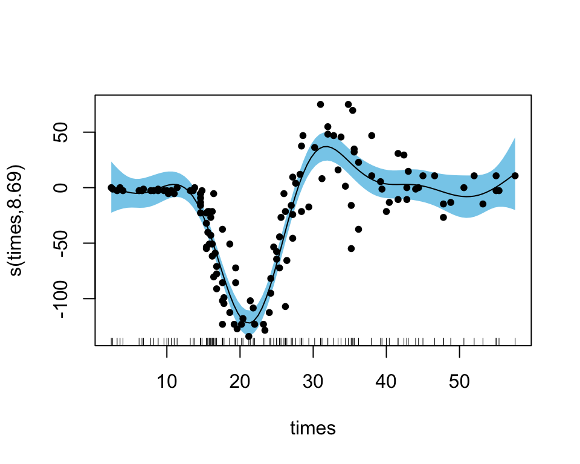

```r
data("mcycle", package = "MASS")

mod <- gam(accel ~ s(times), data = mcycle)

plot(mod, shade = TRUE, shade.col = "skyblue",
     residuals = TRUE, pch = 20,      ## partial residuals
     shift = coefficients(mod)[[1]],  ## shift by value of intercept
     seWithMean = TRUE)               ## include uncertainty of intercept
```

Note. Use `gam.check()` for model diagnostics.

## Concurvity

Concurvity is analogous to collinearity, but it goes a bit further.

> Even if two variables aren’t collinear, they may have concurvity, that is, one may be a smooth curve of another.

For example, $x_1$ and $x_2$ might form a parabola.

Use the `concurvity()` to get an assessment of concurvity.

The `full` argument gives an overall assessment (when `TRUE`) or a pairwise concurvity (when `FALSE`).

```r
mod <- gam(hw.mpg ~ s(length) + s(width) + s(height) + s(weight),
           data = mpg, method = "REML")

## height is least pre-determined by all other variables
concurvity(mod, full = TRUE)
```

```
                 para s(length)  s(width) s(height) s(weight)
worst    1.079374e-20 0.9303404 0.9322887 0.6723705 0.9603887
observed 1.079374e-20 0.7534619 0.8757513 0.4869308 0.8793300
estimate 1.079374e-20 0.8353324 0.7943374 0.4452676 0.8567519
```

```r
## weight and width have the greatest "worst-case" concurvity
concurvity(mod, full = FALSE) %>% map(round, digits = 2)
```

```
$worst
          para s(length) s(width) s(height) s(weight)
para         1      0.00     0.00      0.00      0.00
s(length)    0      1.00     0.83      0.61      0.88
s(width)     0      0.83     1.00      0.41      0.90
s(height)    0      0.61     0.41      1.00      0.37
s(weight)    0      0.88     0.90      0.37      1.00

$observed
          para s(length) s(width) s(height) s(weight)
para         1      0.00     0.00      0.00      0.00
s(length)    0      1.00     0.75      0.28      0.82
s(width)     0      0.51     1.00      0.12      0.78
s(height)    0      0.23     0.33      1.00      0.29
s(weight)    0      0.61     0.79      0.15      1.00

$estimate
          para s(length) s(width) s(height) s(weight)
para         1      0.00     0.00      0.00      0.00
s(length)    0      1.00     0.64      0.23      0.72
s(width)     0      0.65     1.00      0.11      0.72
s(height)    0      0.33     0.26      1.00      0.27
s(weight)    0      0.72     0.69      0.14      1.00
```

## Spatial GAMs

Here, we focus on variables that are best represented by *complex surfaces*, rather than smooth lines.

> A common way to model geospatial data is to use an interaction term of `x` and `y` coordinates, along with individual terms for other predictors. The interaction term then accounts for the spatial structure of the data.

> We represent interactions between variables as a smooth surface, so any combination of variables can take a different value. This is also a natural way to represent spatial data.

```
## Interaction syntax
gam(y ~ s(x1, x2), data = df, method = "REML")
```

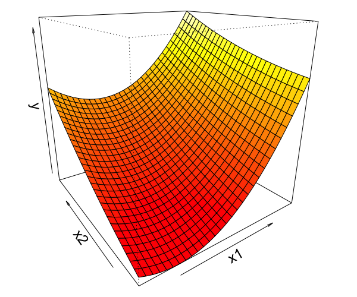

**Example**

```r
data(meuse, package = "sp")
glimpse(meuse)
```

```
Observations: 155
Variables: 14
$ x       <dbl> 181072, 181025, 181165, 181298, 181307, 181390, 181165, …
$ y       <dbl> 333611, 333558, 333537, 333484, 333330, 333260, 333370, …
$ cadmium <dbl> 11.7, 8.6, 6.5, 2.6, 2.8, 3.0, 3.2, 2.8, 2.4, 1.6, 1.4, …
$ copper  <dbl> 85, 81, 68, 81, 48, 61, 31, 29, 37, 24, 25, 25, 93, 31, …
$ lead    <dbl> 299, 277, 199, 116, 117, 137, 132, 150, 133, 80, 86, 97,…
$ zinc    <dbl> 1022, 1141, 640, 257, 269, 281, 346, 406, 347, 183, 189,…
$ elev    <dbl> 7.909, 6.983, 7.800, 7.655, 7.480, 7.791, 8.217, 8.490, …
$ dist    <dbl> 0.00135803, 0.01222430, 0.10302900, 0.19009400, 0.277090…
$ om      <dbl> 13.6, 14.0, 13.0, 8.0, 8.7, 7.8, 9.2, 9.5, 10.6, 6.3, 6.…
$ ffreq   <fct> 1, 1, 1, 1, 1, 1, 1, 1, 1, 1, 1, 1, 1, 1, 1, 1, 1, 1, 1,…
$ soil    <fct> 1, 1, 1, 2, 2, 2, 2, 1, 1, 2, 2, 1, 1, 1, 1, 1, 1, 1, 1,…
$ lime    <fct> 1, 1, 1, 0, 0, 0, 0, 0, 0, 0, 0, 0, 1, 0, 0, 1, 1, 1, 1,…
$ landuse <fct> Ah, Ah, Ah, Ga, Ah, Ga, Ah, Ab, Ab, W, Fh, Ag, W, Ah, Ah…
$ dist.m  <dbl> 50, 30, 150, 270, 380, 470, 240, 120, 240, 420, 400, 300…
```

```r
geo_mod <- gam(cadmium ~ s(x, y) +  ## x, y surface
                 s(elev) +          ## elevation
                 s(dist),           ## distance from river
               data = meuse, method = "REML")

summary(geo_mod)
```

```
Family: gaussian
Link function: identity

Formula:
cadmium ~ s(x, y) + s(elev) + s(dist)

Parametric coefficients:
            Estimate Std. Error t value Pr(>|t|)
(Intercept)   3.2458     0.1238   26.21   <2e-16 ***
---
Signif. codes:  0 '***' 0.001 '**' 0.01 '*' 0.05 '.' 0.1 ' ' 1

Approximate significance of smooth terms:
           edf Ref.df      F  p-value
s(x,y)  20.398 24.599  2.324  0.00078 ***
s(elev)  1.282  1.496 28.868 6.52e-08 ***
s(dist)  6.609  7.698 13.677 5.25e-15 ***
---
Signif. codes:  0 '***' 0.001 '**' 0.01 '*' 0.05 '.' 0.1 ' ' 1

R-sq.(adj) =  0.809   Deviance explained = 84.4%
-REML = 321.06  Scale est. = 2.3762    n = 155
```

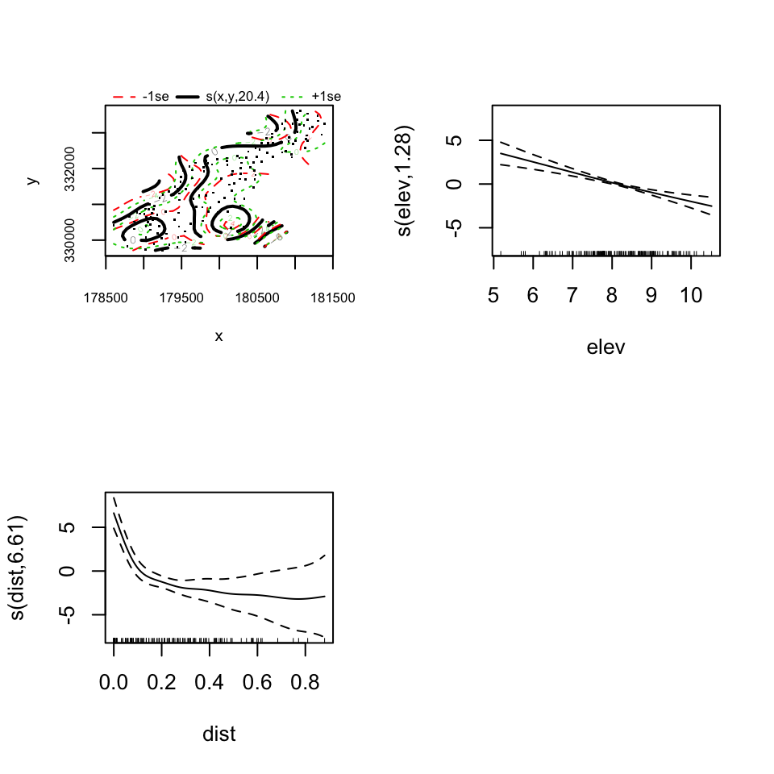

```r
plot(geo_mod, pages = 1)
```

Note that interactions are represented as a contour plot.

> A contour plot is not always the most intuitive way of plotting interactions, so mgcv has a couple of more options [with the `scheme` argument].

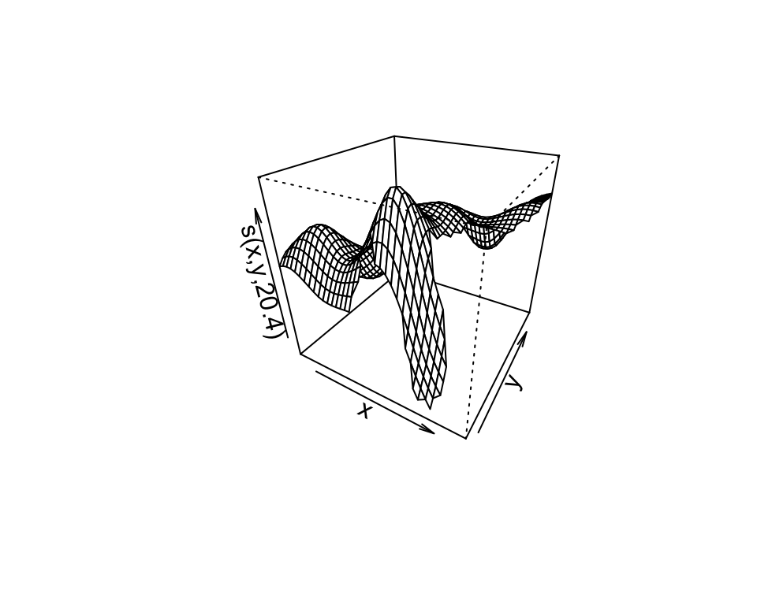

```r
## 3D plot
plot(geo_mod, scheme = 1, select = 1)
```

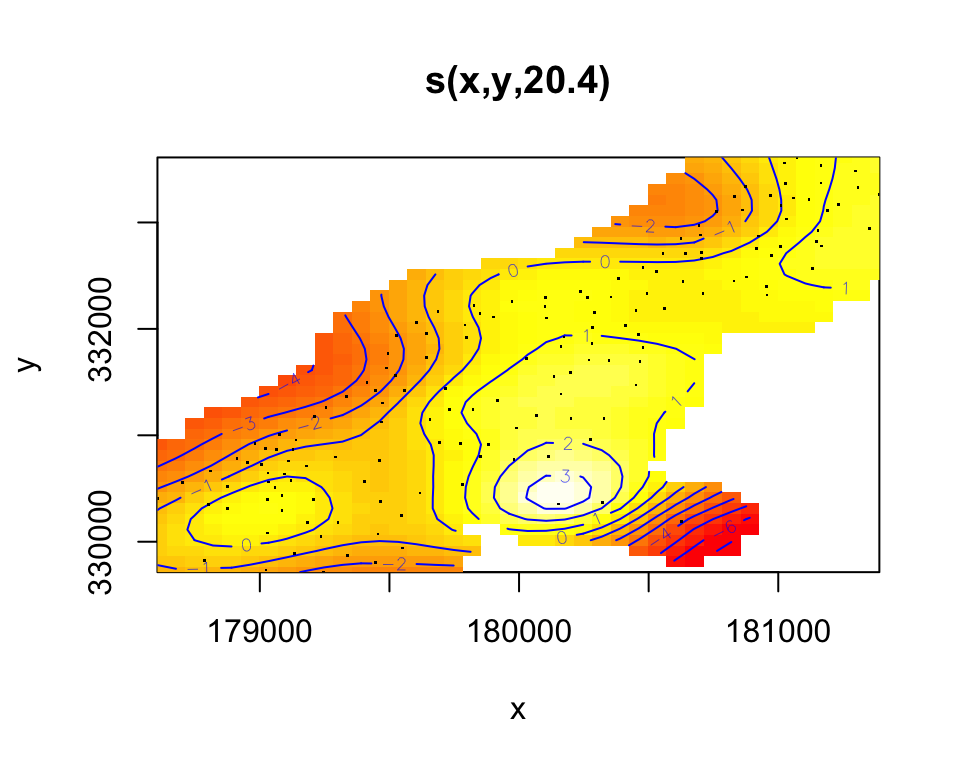

```r
## Heat map (yellow higher, red is lower)
plot(geo_mod, scheme = 2, select = 1)
```

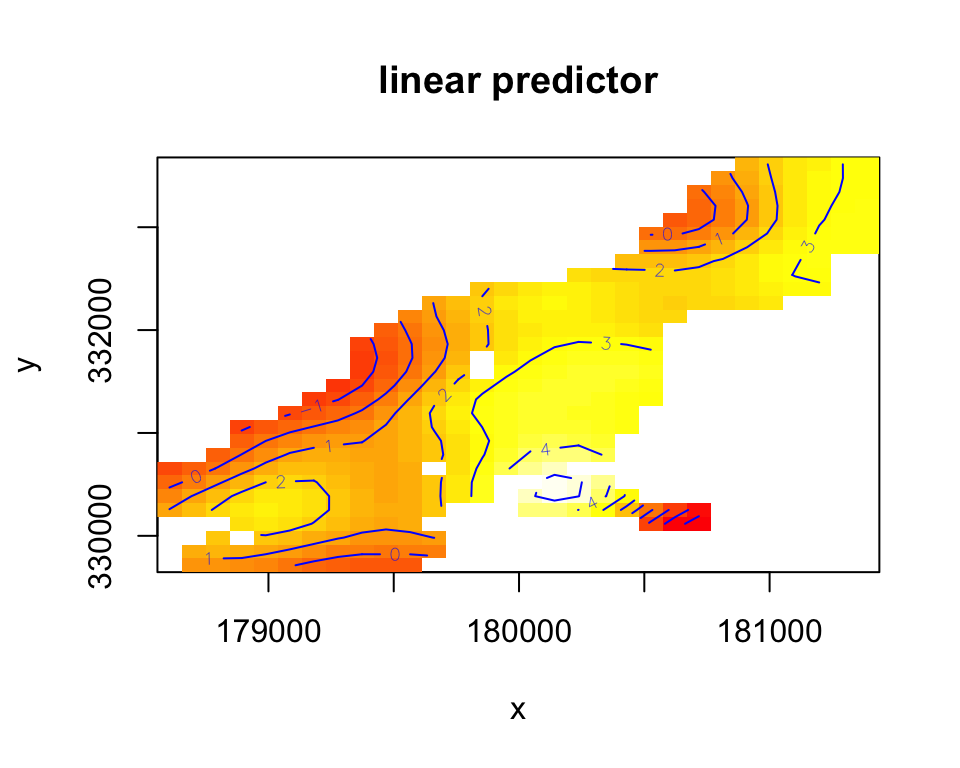

```r
vis.gam(geo_mod, view = c("x", "y"), plot.type = "contour",
        too.far = 0.05)  ## 5% extrapolation
```

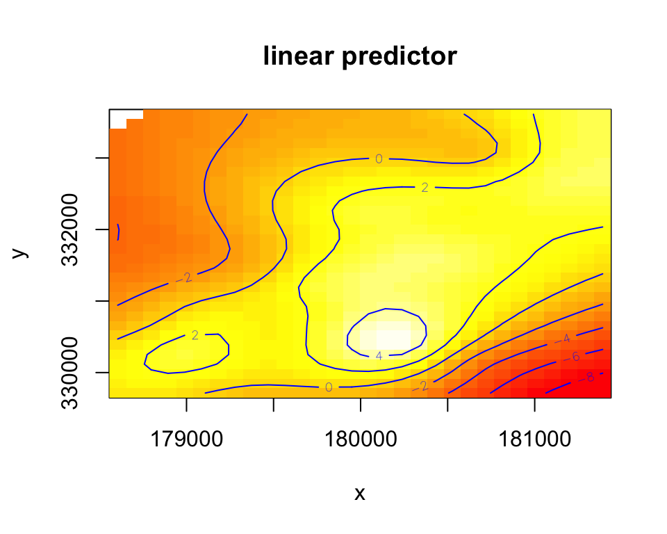

```r
vis.gam(geo_mod, view = c("x", "y"), plot.type = "contour",
        too.far = 0.5)  ## 50% extrapolation
```

## Interactions II

**Factor-smooth interaction.**

Previously, we talked about “categorical-continuous interaction” which were implemented using the `by` argument inside the `s()` function. We also added an additional linear term to make separate intercepts for each level. This last step is unnecessary when we use a so-called **factor-smooth**, which we implement by using the factor-smooth basis type.

```r
mod_sep <- gam(copper ~ s(dist, by = landuse) + landuse,
               data = meuse, method = "REML")

summary(mod_sep)
```

```
Family: gaussian
Link function: identity

Formula:
copper ~ s(dist, by = landuse) + landuse

Parametric coefficients:
            Estimate Std. Error t value Pr(>|t|)
(Intercept)   20.115     46.339   0.434    0.665
landuseAb     15.674     46.611   0.336    0.737
landuseAg      6.670     46.829   0.142    0.887
landuseAh     18.137     46.399   0.391    0.697
landuseAm     13.364     46.442   0.288    0.774
landuseB       0.825     62.982   0.013    0.990
landuseBw     18.909     46.759   0.404    0.687
landuseDEN     0.000      0.000      NA       NA
landuseFh      4.885    155.443   0.031    0.975
landuseFw     18.578     46.575   0.399    0.691
landuseGa    122.541     99.227   1.235    0.219
landuseSPO     1.885    146.517   0.013    0.990
landuseSTA     3.261     49.286   0.066    0.947
landuseTv      4.885    134.315   0.036    0.971
landuseW      18.917     46.445   0.407    0.685

Approximate significance of smooth terms:
                          edf     Ref.df      F  p-value
s(dist):landuseAa   1.000e+00  1.000e+00  0.000  0.98367
s(dist):landuseAb   1.000e+00  1.000e+00  1.672  0.19842
s(dist):landuseAg   1.000e+00  1.000e+00  0.442  0.50767
s(dist):landuseAh   2.524e+00  3.113e+00  8.725 2.11e-05 ***
s(dist):landuseAm   1.000e+00  1.000e+00  6.802  0.01022 *
s(dist):landuseB    1.000e+00  1.000e+00  0.023  0.87889
s(dist):landuseBw   1.000e+00  1.000e+00  0.047  0.82886
s(dist):landuseDEN  1.000e+00  1.000e+00  0.042  0.83866
s(dist):landuseFh   1.368e-15  1.368e-15  0.000  1.00000
s(dist):landuseFw   2.696e+00  3.304e+00  5.292  0.00131 **
s(dist):landuseGa   1.882e+00  1.986e+00  0.654  0.49474
s(dist):landuseSPO -5.950e-18 -5.950e-18  0.000  1.00000
s(dist):landuseSTA  1.000e+00  1.000e+00  0.005  0.94455
s(dist):landuseTv   1.182e-15  1.182e-15  0.000  1.00000
s(dist):landuseW    4.009e+00  4.814e+00 32.861  < 2e-16 ***
---
Signif. codes:  0 '***' 0.001 '**' 0.01 '*' 0.05 '.' 0.1 ' ' 1

Rank: 146/150
R-sq.(adj) =  0.634   Deviance explained = 71.1%
-REML = 532.81  Scale est. = 199.48    n = 154
```

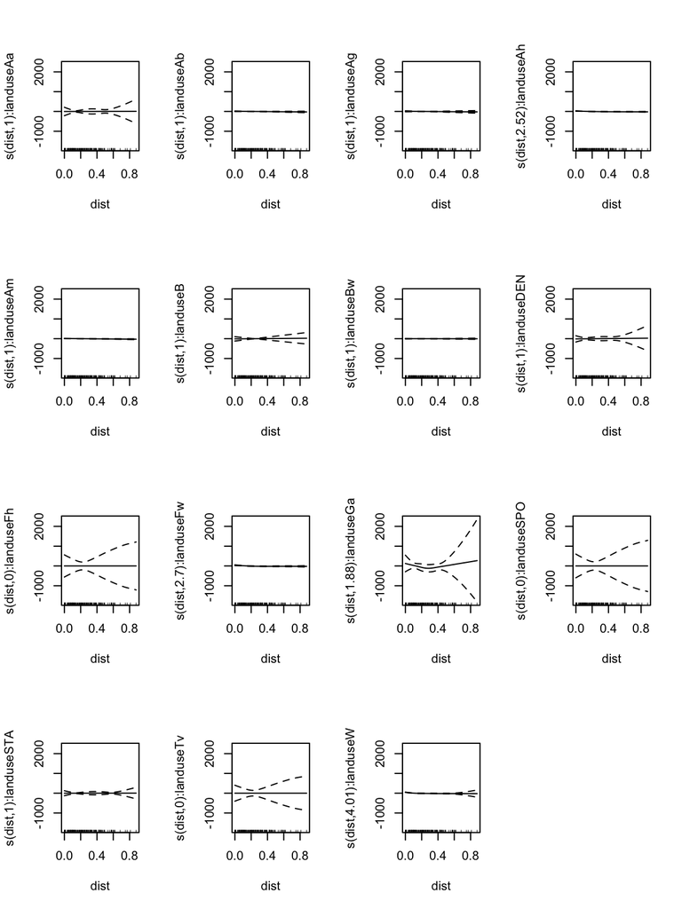

```r
plot(mod_sep, pages = 1)
```

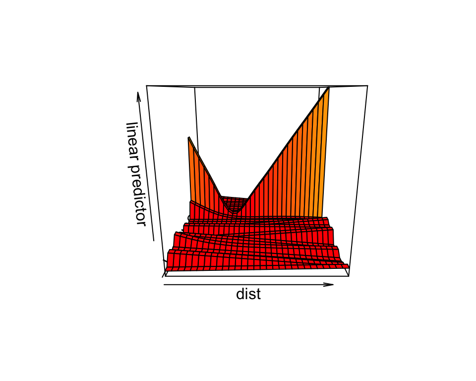

```r
vis.gam(mod_sep, view = c("dist", "landuse"), plot.type = "persp")
```

```r
mod_fs <- gam(copper ~ s(dist, landuse, bs = "fs"),
              data = meuse, method = "REML")

summary(mod_fs)
```

```
Family: gaussian
Link function: identity

Formula:
copper ~ s(dist, landuse, bs = "fs")

Parametric coefficients:
            Estimate Std. Error t value Pr(>|t|)
(Intercept)    30.07       3.33   9.031 1.43e-15 ***
---
Signif. codes:  0 '***' 0.001 '**' 0.01 '*' 0.05 '.' 0.1 ' ' 1

Approximate significance of smooth terms:
                  edf Ref.df     F p-value
s(dist,landuse) 16.37     71 2.463  <2e-16 ***
---
Signif. codes:  0 '***' 0.001 '**' 0.01 '*' 0.05 '.' 0.1 ' ' 1

R-sq.(adj) =  0.533   Deviance explained = 58.3%
-REML = 659.94  Scale est. = 254.2     n = 154
```

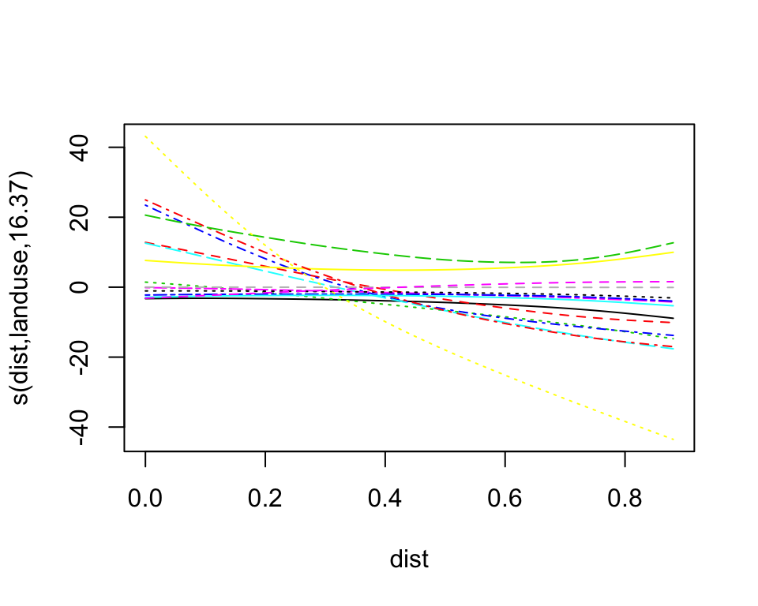

```r
plot(mod_fs, pages = 1)
```

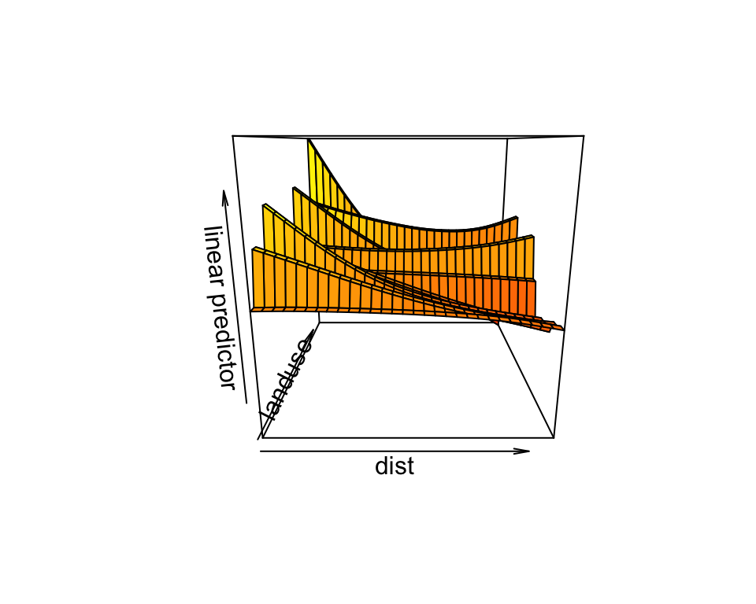

```r
vis.gam(mod_fs, view = c("dist", "landuse"), plot.type = "persp")
```

> With factor-smooths, we do not get a different term for each level of the categorical variable. Rather, we get one overall interaction term. This means that they are not as good for distinguishing between categories. However, factor smooths are good for controlling for the effects of categories that are not our main variables of interest, especially when there are very many categories, or only a few data points in some categories.

## Interactions III

**Tensor-smooth interaction.**

> Tensor smooths let us model interactions that operate on different scales, such as space and time.

$$y = te(x_1, x_2) \hspace{1cm} \text{with smoothing parameters } \lambda_1, \ \lambda_2$$

> Tensor smooths are more appropriate for interactions of variables with different scales or units. A tensor is similar to a regular two-dimensional smooth, but it has two smoothing parameters, one for each variable.

> Tensor smooths are used similarly to regular smooths, one just uses `te()` instead of `s()` for them. Since there are multiple smoothing parameters, you can specify a different number of basis functions, or `k` values, for each smooth.

> One other great advantage of tensor smooths is that they can be used to separate out interactions from individual univariate effects. Using **tensor interactions**, we can model only the interaction of two variables, and not their independent effects, which we estimate separately.

$$y = s(x_1) + s(x_2) + ti(x_1, x_2) \\\\ \text{with smoothing parameters } \lambda_1, \ \lambda_2 \ \lambda_3 \ \lambda_4$$

> Note that each of these components has its own smoothing parameters and can have its own number of basis functions. This means we are estimating more parameters. Necessarily, such models need more data.

```r
geo_tensor_mod <- gam(cadmium ~ te(x, y, elev),
                      data = meuse, method = "REML")

summary(geo_tensor_mod)
```

```
Family: gaussian
Link function: identity

Formula:
cadmium ~ te(x, y, elev)

Parametric coefficients:
            Estimate Std. Error t value Pr(>|t|)
(Intercept)   3.2458     0.1329   24.43   <2e-16 ***
---
Signif. codes:  0 '***' 0.001 '**' 0.01 '*' 0.05 '.' 0.1 ' ' 1

Approximate significance of smooth terms:
               edf Ref.df     F p-value
te(x,y,elev) 38.29  45.86 11.87  <2e-16 ***
---
Signif. codes:  0 '***' 0.001 '**' 0.01 '*' 0.05 '.' 0.1 ' ' 1

R-sq.(adj) =   0.78   Deviance explained = 83.4%
-REML = 318.09  Scale est. = 2.7358    n = 155
```

```r
## separating interacting and independent effects
geo_tensor_mod2 <- gam(cadmium ~ s(x, y) + s(elev) + ti(x, y),
                       data = meuse, method = "REML")

summary(geo_tensor_mod2)
```

[output not shown]